# Health and Economic Impact of Weather Events in the US

Assignment Week 4 Reproducible Research

TG

Thursday, June 2, 2016

# Impact of severe weather events on public health and economic results

# Synopsis

Storms and other severe weather events can cause both public health and economic problems for communities and municipalities. Many severe events can result in fatalities, injuries, and property damage, and preventing such outcomes to the extent possible is a key concern. This project involves exploring the U.S. National Oceanic and Atmospheric Administration’s (NOAA) storm database. This database tracks characteristics of major storms and weather events in the United States, including when and where they occur, as well as estimates of any fatalities, injuries, and property damage.

This data analysis addresses the following questions:

1. Across the United States, which types of events are most harmful with respect to population health.
2. Across the United States, which types of events have the greatest economic consequences.

General Notes

Assumption: all packages are pre-installed.

# 0. Prepare the environment.

### Set the Working directory

```r
setwd("H:/Coursera/Data Scientist/Reproducible Research/week 4")
```

### Load relevant Packages

```r
#install.packages("dplyr")
library(dplyr)
```

```r
library(ggplot2)
library(readr)
```

### clear workspace

```r
rm(list=ls())
```

### Set the Working directory

```r
setwd("H:/Coursera/Data Scientist/Reproducible Research/week 4")
```

### Load raw data

```r
if (! file.exists('stormData.csv.bz2'))
  {
download.file("http://d396qusza40orc.cloudfront.net/repdata%2Fdata%2FStormData.csv.bz2","StormData.csv.bz2")
input_data <- read_csv("StormData.csv.bz2")
message("data downloaded")
}else   {
  message("continue with already available data ")
}
```

```
## continue with already available data
```

```r
if (! exists('input_data'))
  {
input_data <- read_csv("StormData.csv.bz2")
message("data loaded")
}else   {
  message("continue with already available data ")
}
```

```
## data loaded
```

# 1. Prepare the data: Data Preprocessing.

### Define the table

```r
tbl_input_data <- tbl_df(input_data)
```

### Explore the dataset

```r
dim(input_data)
```

```
## [1] 902297     37
```

```r
summary(input_data)
```

```
##     STATE__       BGN_DATE           BGN_TIME          TIME_ZONE
##  Min.   : 1.0   Length:902297      Length:902297      Length:902297
##  1st Qu.:19.0   Class :character   Class :character   Class :character
##  Median :30.0   Mode  :character   Mode  :character   Mode  :character
##  Mean   :31.2
##  3rd Qu.:45.0
##  Max.   :95.0
##
##      COUNTY       COUNTYNAME           STATE              EVTYPE
##  Min.   :  0.0   Length:902297      Length:902297      Length:902297
##  1st Qu.: 31.0   Class :character   Class :character   Class :character
##  Median : 75.0   Mode  :character   Mode  :character   Mode  :character
##  Mean   :100.6
##  3rd Qu.:131.0
##  Max.   :873.0
##
##    BGN_RANGE          BGN_AZI           BGN_LOCATI
##  Min.   :   0.000   Length:902297      Length:902297
##  1st Qu.:   0.000   Class :character   Class :character
##  Median :   0.000   Mode  :character   Mode  :character
##  Mean   :   1.484
##  3rd Qu.:   1.000
##  Max.   :3749.000
##
##    END_DATE           END_TIME           COUNTY_END  COUNTYENDN
##  Length:902297      Length:902297      Min.   :0    Length:902297
##  Class :character   Class :character   1st Qu.:0    Class :character
##  Mode  :character   Mode  :character   Median :0    Mode  :character
##                                        Mean   :0
##                                        3rd Qu.:0
##                                        Max.   :0
##
##    END_RANGE          END_AZI           END_LOCATI
##  Min.   :  0.0000   Length:902297      Length:902297
##  1st Qu.:  0.0000   Class :character   Class :character
##  Median :  0.0000   Mode  :character   Mode  :character
##  Mean   :  0.9862
##  3rd Qu.:  0.0000
##  Max.   :925.0000
##
```

[output cut: 33 more lines]

```
##  Min.   :-14451   Min.   :   0   Min.   :-14455   Length:902297
##  1st Qu.:  7247   1st Qu.:   0   1st Qu.:     0   Class :character
##  Median :  8707   Median :   0   Median :     0   Mode  :character
##  Mean   :  6940   Mean   :1452   Mean   :  3509
##  3rd Qu.:  9605   3rd Qu.:3549   3rd Qu.:  8735
##  Max.   : 17124   Max.   :9706   Max.   :106220
##                   NA's   :40
##      REFNUM
##  Min.   :     1
##  1st Qu.:225575
##  Median :451149
##  Mean   :451149
##  3rd Qu.:676723
##  Max.   :902297
##
```

```r
head(input_data)
```

```
## Source: local data frame [6 x 37]
##
##   STATE__           BGN_DATE BGN_TIME TIME_ZONE COUNTY COUNTYNAME STATE
##     (dbl)              (chr)    (chr)     (chr)  (dbl)      (chr) (chr)
## 1       1  4/18/1950 0:00:00     0130       CST     97     MOBILE    AL
## 2       1  4/18/1950 0:00:00     0145       CST      3    BALDWIN    AL
## 3       1  2/20/1951 0:00:00     1600       CST     57    FAYETTE    AL
## 4       1   6/8/1951 0:00:00     0900       CST     89    MADISON    AL
## 5       1 11/15/1951 0:00:00     1500       CST     43    CULLMAN    AL
## 6       1 11/15/1951 0:00:00     2000       CST     77 LAUDERDALE    AL
## Variables not shown: EVTYPE (chr), BGN_RANGE (dbl), BGN_AZI (chr),
##   BGN_LOCATI (chr), END_DATE (chr), END_TIME (chr), COUNTY_END (dbl),
##   COUNTYENDN (chr), END_RANGE (dbl), END_AZI (chr), END_LOCATI (chr),
##   LENGTH (dbl), WIDTH (dbl), F (int), MAG (dbl), FATALITIES (dbl),
##   INJURIES (dbl), PROPDMG (dbl), PROPDMGEXP (chr), CROPDMG (dbl),
##   CROPDMGEXP (chr), WFO (chr), STATEOFFIC (chr), ZONENAMES (chr), LATITUDE
##   (dbl), LONGITUDE (dbl), LATITUDE_E (dbl), LONGITUDE_ (dbl), REMARKS
##   (chr), REFNUM (dbl)
```

```r
glimpse(tbl_input_data)
```

```
## Observations: 902,297
## Variables: 37
## $ STATE__    (dbl) 1, 1, 1, 1, 1, 1, 1, 1, 1, 1, 1, 1, 1, 1, 1, 1, 1, ...
## $ BGN_DATE   (chr) "4/18/1950 0:00:00", "4/18/1950 0:00:00", "2/20/195...
## $ BGN_TIME   (chr) "0130", "0145", "1600", "0900", "1500", "2000", "01...
## $ TIME_ZONE  (chr) "CST", "CST", "CST", "CST", "CST", "CST", "CST", "C...
## $ COUNTY     (dbl) 97, 3, 57, 89, 43, 77, 9, 123, 125, 57, 43, 9, 73, ...
## $ COUNTYNAME (chr) "MOBILE", "BALDWIN", "FAYETTE", "MADISON", "CULLMAN...
## $ STATE      (chr) "AL", "AL", "AL", "AL", "AL", "AL", "AL", "AL", "AL...
## $ EVTYPE     (chr) "TORNADO", "TORNADO", "TORNADO", "TORNADO", "TORNAD...
## $ BGN_RANGE  (dbl) 0, 0, 0, 0, 0, 0, 0, 0, 0, 0, 0, 0, 0, 0, 0, 0, 0, ...
## $ BGN_AZI    (chr) NA, NA, NA, NA, NA, NA, NA, NA, NA, NA, NA, NA, NA,...
## $ BGN_LOCATI (chr) NA, NA, NA, NA, NA, NA, NA, NA, NA, NA, NA, NA, NA,...
## $ END_DATE   (chr) NA, NA, NA, NA, NA, NA, NA, NA, NA, NA, NA, NA, NA,...
## $ END_TIME   (chr) NA, NA, NA, NA, NA, NA, NA, NA, NA, NA, NA, NA, NA,...
```

[output cut: 24 more lines]

```r
tbl_input_data
```

```
## Source: local data frame [902,297 x 37]
##
##    STATE__           BGN_DATE BGN_TIME TIME_ZONE COUNTY COUNTYNAME STATE
##      (dbl)              (chr)    (chr)     (chr)  (dbl)      (chr) (chr)
## 1        1  4/18/1950 0:00:00     0130       CST     97     MOBILE    AL
## 2        1  4/18/1950 0:00:00     0145       CST      3    BALDWIN    AL
## 3        1  2/20/1951 0:00:00     1600       CST     57    FAYETTE    AL
## 4        1   6/8/1951 0:00:00     0900       CST     89    MADISON    AL
## 5        1 11/15/1951 0:00:00     1500       CST     43    CULLMAN    AL
## 6        1 11/15/1951 0:00:00     2000       CST     77 LAUDERDALE    AL
## 7        1 11/16/1951 0:00:00     0100       CST      9     BLOUNT    AL
## 8        1  1/22/1952 0:00:00     0900       CST    123 TALLAPOOSA    AL
## 9        1  2/13/1952 0:00:00     2000       CST    125 TUSCALOOSA    AL
## 10       1  2/13/1952 0:00:00     2000       CST     57    FAYETTE    AL
## ..     ...                ...      ...       ...    ...        ...   ...
## Variables not shown: EVTYPE (chr), BGN_RANGE (dbl), BGN_AZI (chr),
##   BGN_LOCATI (chr), END_DATE (chr), END_TIME (chr), COUNTY_END (dbl),
##   COUNTYENDN (chr), END_RANGE (dbl), END_AZI (chr), END_LOCATI (chr),
##   LENGTH (dbl), WIDTH (dbl), F (int), MAG (dbl), FATALITIES (dbl),
##   INJURIES (dbl), PROPDMG (dbl), PROPDMGEXP (chr), CROPDMG (dbl),
##   CROPDMGEXP (chr), WFO (chr), STATEOFFIC (chr), ZONENAMES (chr), LATITUDE
##   (dbl), LONGITUDE (dbl), LATITUDE_E (dbl), LONGITUDE_ (dbl), REMARKS
##   (chr), REFNUM (dbl)
```

```r
rm(input_data)
```

### Extract the relevant sub-dataset

In order to answer the specific questions it is required to build a subset to perform the resp analysis:

- BGN_DATE,
- STATE,
- EVTYPE,
- FATALITIES,
- INJURIES,
- PROPDMG,
- PROPDMGEXP,
- CROPDMG,
- CROPDMGEXP

```r
sub_input_data<-tbl_input_data  %>% select(BGN_DATE,STATE, EVTYPE, FATALITIES, INJURIES, PROPDMG, PROPDMGEXP,CROPDMG,CROPDMGEXP)
sub_input_data
```

```
## Source: local data frame [902,297 x 9]
##
##              BGN_DATE STATE  EVTYPE FATALITIES INJURIES PROPDMG PROPDMGEXP
##                 (chr) (chr)   (chr)      (dbl)    (dbl)   (dbl)      (chr)
## 1   4/18/1950 0:00:00    AL TORNADO          0       15    25.0          K
## 2   4/18/1950 0:00:00    AL TORNADO          0        0     2.5          K
## 3   2/20/1951 0:00:00    AL TORNADO          0        2    25.0          K
## 4    6/8/1951 0:00:00    AL TORNADO          0        2     2.5          K
## 5  11/15/1951 0:00:00    AL TORNADO          0        2     2.5          K
## 6  11/15/1951 0:00:00    AL TORNADO          0        6     2.5          K
## 7  11/16/1951 0:00:00    AL TORNADO          0        1     2.5          K
## 8   1/22/1952 0:00:00    AL TORNADO          0        0     2.5          K
## 9   2/13/1952 0:00:00    AL TORNADO          1       14    25.0          K
## 10  2/13/1952 0:00:00    AL TORNADO          0        0    25.0          K
## ..                ...   ...     ...        ...      ...     ...        ...
## Variables not shown: CROPDMG (dbl), CROPDMGEXP (chr)
```

```r
rm(tbl_input_data)
```

### Inspect the relevant values

In order to answer the specific questions it is required to asses the respective value ranges to perform the respective transformations:

```r
sub_input_data %>% sample_n(50)
```

```
## Source: local data frame [50 x 9]
##
##              BGN_DATE STATE            EVTYPE FATALITIES INJURIES PROPDMG
##                 (chr) (chr)             (chr)      (dbl)    (dbl)   (dbl)
## 1   3/17/1987 0:00:00    TX         TSTM WIND          0        0     0.0
## 2    6/7/1984 0:00:00    MN         TSTM WIND          0        0     0.0
## 3    8/9/1995 0:00:00    OH       FLASH FLOOD          0        0     2.0
## 4   6/10/2010 0:00:00    CO              HAIL          0        0     0.0
## 5    6/3/2009 0:00:00    KY THUNDERSTORM WIND          0        0     0.0
## 6  12/18/2008 0:00:00    IA         ICE STORM          0        0     0.0
## 7   7/20/1995 0:00:00    NC         LIGHTNING          0        0     0.0
## 8  10/12/1997 0:00:00    CA         HIGH WIND          0        0     0.0
## 9   7/14/1973 0:00:00    OH           TORNADO          0        0     2.5
## 10 12/27/2010 0:00:00    FL      FROST/FREEZE          0        0     0.0
## ..                ...   ...               ...        ...      ...     ...
## Variables not shown: PROPDMGEXP (chr), CROPDMG (dbl), CROPDMGEXP (chr)
```

```r
glimpse(sub_input_data)
```

```
## Observations: 902,297
## Variables: 9
## $ BGN_DATE   (chr) "4/18/1950 0:00:00", "4/18/1950 0:00:00", "2/20/195...
## $ STATE      (chr) "AL", "AL", "AL", "AL", "AL", "AL", "AL", "AL", "AL...
## $ EVTYPE     (chr) "TORNADO", "TORNADO", "TORNADO", "TORNADO", "TORNAD...
## $ FATALITIES (dbl) 0, 0, 0, 0, 0, 0, 0, 0, 1, 0, 0, 0, 1, 0, 0, 4, 0, ...
## $ INJURIES   (dbl) 15, 0, 2, 2, 2, 6, 1, 0, 14, 0, 3, 3, 26, 12, 6, 50...
## $ PROPDMG    (dbl) 25.0, 2.5, 25.0, 2.5, 2.5, 2.5, 2.5, 2.5, 25.0, 25....
## $ PROPDMGEXP (chr) "K", "K", "K", "K", "K", "K", "K", "K", "K", "K", "...
## $ CROPDMG    (dbl) 0, 0, 0, 0, 0, 0, 0, 0, 0, 0, 0, 0, 0, 0, 0, 0, 0, ...
## $ CROPDMGEXP (chr) NA, NA, NA, NA, NA, NA, NA, NA, NA, NA, NA, NA, NA,...
```

```r
dist_EVTYPE<-sub_input_data %>%distinct(EVTYPE)%>%select(EVTYPE)
dist_STATE<-sub_input_data %>%distinct(STATE)%>%select(STATE)
dist_BGN_DATE <-sub_input_data %>%distinct(BGN_DATE)%>%select(BGN_DATE)
dist_EVTYPE <-sub_input_data %>%distinct(EVTYPE)%>%select(EVTYPE)%>%arrange( desc(EVTYPE))
dist_FATALITIES <-sub_input_data %>%distinct(FATALITIES)%>%select(FATALITIES)
dist_INJURIES <-sub_input_data %>%distinct(INJURIES)%>%select(INJURIES)
dist_PROPDMG <-sub_input_data %>%distinct(PROPDMG)%>%select(PROPDMG)
dist_PROPDMGEXP <-sub_input_data %>%distinct(PROPDMGEXP)%>%select(PROPDMGEXP)
dist_CROPDMG <-sub_input_data %>%distinct(CROPDMG)%>%select(CROPDMG)
dist_CROPDMGEXP <-sub_input_data %>%distinct(CROPDMGEXP)%>%select(CROPDMGEXP)
```

```r
print(dist_STATE )
```

```
## Source: local data frame [72 x 1]
##
##    STATE
##    (chr)
## 1     AL
## 2     AZ
## 3     AR
## 4     CA
## 5     CO
## 6     CT
## 7     DE
## 8     DC
## 9     FL
## 10    GA
## ..   ...
```

Conclusion: For STATE, there’s no need for transformation.

```r
print(dist_BGN_DATE )
```

```
## Source: local data frame [16,335 x 1]
##
##              BGN_DATE
##                 (chr)
## 1   4/18/1950 0:00:00
## 2   2/20/1951 0:00:00
## 3    6/8/1951 0:00:00
## 4  11/15/1951 0:00:00
## 5  11/16/1951 0:00:00
## 6   1/22/1952 0:00:00
## 7   2/13/1952 0:00:00
## 8   2/29/1952 0:00:00
## 9    3/3/1952 0:00:00
## 10  3/22/1952 0:00:00
## ..                ...
```

Conclusion: For BGN_DATE, there’s no need for transformation.

```r
print(dist_EVTYPE )
```

```
## Source: local data frame [977 x 1]
##
##                EVTYPE
##                 (chr)
## 1                 WND
## 2          WINTRY MIX
## 3          Wintry Mix
## 4          Wintry mix
## 5         WINTERY MIX
## 6  WINTER WEATHER/MIX
## 7  WINTER WEATHER MIX
## 8      WINTER WEATHER
## 9      Winter Weather
## 10      WINTER STORMS
## ..                ...
```

Conclusion: For dist_EVTYPE, there’s a need for transformation. Data Quality improvement action is required. If not: aggregation on this variable might generate misleading results. **Action:** As there’s no mapping table given or available a manual table has to be created. Input to this manual exercise is the table dist_EVTYPE.

Therefore a manual table (dist_EVTYPE_Mapping.csv) is created by aggregating and categorising events based on obvious semantical similarities. Further investigations might lead to more advanced categories.

The file store is:https://github.com/Schelm56/courses-05_ReproducibleResearch-my_data/blob/master/dist_EVTYPE_Mapping.csv

```r
if (! file.exists('dist_EVTYPE_Mapping.csv'))
  {
download.file("https://github.com/Schelm56/courses-05_ReproducibleResearch-my_data/blob/master/dist_EVTYPE_Mapping.csv","dist_EVTYPE_Mapping.csv")
dist_EVTYPE_Mapping <- read_delim("dist_EVTYPE_Mapping.csv",col_names = TRUE,delim = ";")
message("data downloaded")
}else   {
  message("continue with already available data ")
}
```

```
## continue with already available data
```

```r
if (! exists('dist_EVTYPE_Mapping'))
  {

dist_EVTYPE_Mapping <- read_delim("dist_EVTYPE_Mapping.csv",col_names = TRUE,delim = ";")
message("data loaded")
}else   {
  message("continue with already available data ")
}
```

```
## data loaded
```

```r
print(dist_EVTYPE_Mapping)
```

```
## Source: local data frame [977 x 2]
##
##                EVTYPE     EVTYPE_New
##                 (chr)          (chr)
## 1                 WND           WIND
## 2          WINTRY MIX Winter Weather
## 3          Wintry Mix Winter Weather
## 4          Wintry mix Winter Weather
## 5         WINTERY MIX Winter Weather
## 6  WINTER WEATHER/MIX Winter Weather
## 7  WINTER WEATHER MIX Winter Weather
## 8      WINTER WEATHER Winter Weather
## 9      Winter Weather Winter Weather
## 10      WINTER STORMS  WINTER STORMS
## ..                ...            ...
```

```r
evt_input_data<-left_join(sub_input_data,dist_EVTYPE_Mapping,by="EVTYPE")
dist_EVTYPE_New <-evt_input_data %>%distinct(EVTYPE_New)%>%select(EVTYPE_New)%>%arrange( desc(EVTYPE_New))
print(dist_EVTYPE_New )
```

```
## Source: local data frame [220 x 1]
##
##        EVTYPE_New
##             (chr)
## 1  Winter Weather
## 2   WINTER STORMS
## 3       WIND/HAIL
## 4      WIND STORM
## 5      WIND GUSTS
## 6     WIND DAMAGE
## 7      WIND CHILL
## 8   WIND AND WAVE
## 9   WIND ADVISORY
## 10           WIND
## ..            ...
```

```r
glimpse(dist_EVTYPE_New)
```

```
## Observations: 220
## Variables: 1
## $ EVTYPE_New (chr) "Winter Weather", "WINTER STORMS", "WIND/HAIL", "WI...
```

**Result:**

By executing the dist_EVTYPE_Mapping the events have been reduced from 977 to 220.

```r
print(dist_FATALITIES )
```

```
## Source: local data frame [52 x 1]
##
##    FATALITIES
##         (dbl)
## 1           0
## 2           1
## 3           4
## 4           6
## 5           7
## 6           2
## 7           5
## 8          25
## 9           3
## 10         10
## ..        ...
```

Conclusion: For FATALITIES, there’s no need for transformation.

```r
print(dist_INJURIES )
```

```
## Source: local data frame [200 x 1]
##
##    INJURIES
##       (dbl)
## 1        15
## 2         0
## 3         2
## 4         6
## 5         1
## 6        14
## 7         3
## 8        26
## 9        12
## 10       50
## ..      ...
```

Conclusion: For INJURIES, there’s no need for transformation.

```r
print(dist_PROPDMG )
```

```
## Source: local data frame [1,390 x 1]
##
##    PROPDMG
##      (dbl)
## 1    25.00
## 2     2.50
## 3   250.00
## 4     0.00
## 5     0.03
## 6     0.25
## 7     5.00
## 8     0.10
## 9    50.00
## 10  500.00
## ..     ...
```

Conclusion: For PROPDMG, there’s no need for transformation.

```r
print(dist_PROPDMGEXP )
```

```
## Source: local data frame [19 x 1]
##
##    PROPDMGEXP
##         (chr)
## 1           K
## 2           M
## 3          NA
## 4           B
## 5           m
## 6           +
## 7           0
## 8           5
## 9           6
## 10          ?
## 11          4
## 12          2
## 13          3
## 14          h
## 15          7
## 16          H
## 17          -
## 18          1
## 19          8
```

Conclusion: For PROPDMGEXP, there’s a need for transformation.Data Quality improvement action is required.In the raw data, the property damage is represented with two fields, a number PROPDMG in dollars and the exponent PROPDMGEXP.

As there’s no mapping table given or available a manual table has to be created.Input to this manual exercise is the table dist_PROPDMGEXP.

Therefore a manual table (dist_PROPDMGEXP_Clean.csv) is created by transforming exponents into real values. Cryptic or non-calculation-ready signs are converted to 0.

The file store is: https://github.com/Schelm56/courses-05_ReproducibleResearch-my_data/blob/master/dist_PROPDMGEXP_Clean.csv

```r
if (! file.exists('dist_PROPDMGEXP_Clean.csv'))
  {
download.file("https://github.com/Schelm56/courses-05_ReproducibleResearch-my_data/blob/master/dist_PROPDMGEXP_Clean.csv","dist_PROPDMGEXP_Clean.csv")
dist_PROPDMGEXP_Clean <- read_delim("ddist_PROPDMGEXP_Clean.csv",col_names = TRUE,delim = ";")
message("data downloaded")
}else   {
  message("continue with already available data ")
}
```

```
## continue with already available data
```

```r
if (! exists('dist_PROPDMGEXP_Clean'))
  {

dist_PROPDMGEXP_Clean <- read_delim("dist_PROPDMGEXP_Clean.csv",col_names = TRUE,delim = ";")
message("data loaded")
}else   {
  message("continue with already available data ")
}
```

```
## data loaded
```

```r
pr_ex_clean_data<-left_join(evt_input_data,dist_PROPDMGEXP_Clean,by="PROPDMGEXP")
print(dist_PROPDMGEXP_Clean )
```

```
## Source: local data frame [19 x 2]
##
##    PROPDMGEXP PROPDM_EXP_Clean
##         (chr)            (int)
## 1           K                3
## 2           M                6
## 3          NA                0
## 4           B                9
## 5           m                6
## 6           +                0
## 7           0                0
## 8           5                5
## 9           6                6
## 10          ?                0
## 11          4                4
## 12          2                2
## 13          3                3
## 14          h                2
## 15          7                7
## 16          H                2
## 17          -                0
## 18          1                1
## 19          8                8
```

```r
print(pr_ex_clean_data )
```

```
## Source: local data frame [914,020 x 11]
##
##              BGN_DATE STATE  EVTYPE FATALITIES INJURIES PROPDMG PROPDMGEXP
##                 (chr) (chr)   (chr)      (dbl)    (dbl)   (dbl)      (chr)
## 1   4/18/1950 0:00:00    AL TORNADO          0       15    25.0          K
## 2   4/18/1950 0:00:00    AL TORNADO          0        0     2.5          K
## 3   2/20/1951 0:00:00    AL TORNADO          0        2    25.0          K
## 4    6/8/1951 0:00:00    AL TORNADO          0        2     2.5          K
## 5  11/15/1951 0:00:00    AL TORNADO          0        2     2.5          K
## 6  11/15/1951 0:00:00    AL TORNADO          0        6     2.5          K
## 7  11/16/1951 0:00:00    AL TORNADO          0        1     2.5          K
## 8   1/22/1952 0:00:00    AL TORNADO          0        0     2.5          K
## 9   2/13/1952 0:00:00    AL TORNADO          1       14    25.0          K
## 10  2/13/1952 0:00:00    AL TORNADO          0        0    25.0          K
## ..                ...   ...     ...        ...      ...     ...        ...
## Variables not shown: CROPDMG (dbl), CROPDMGEXP (chr), EVTYPE_New (chr),
##   PROPDM_EXP_Clean (int)
```

Conclusion: Calculations on Property Damage can be properly executed

```r
print(dist_CROPDMG )
```

```
## Source: local data frame [432 x 1]
##
##    CROPDMG
##      (dbl)
## 1      0.0
## 2     10.0
## 3    500.0
## 4      1.0
## 5      4.0
## 6     50.0
## 7      5.0
## 8     15.0
## 9      0.5
## 10     0.4
## ..     ...
```

Conclusion: For CROPDMG, there’s no need for transformation.

```r
print(dist_CROPDMGEXP )
```

```
## Source: local data frame [9 x 1]
##
##   CROPDMGEXP
##        (chr)
## 1         NA
## 2          M
## 3          K
## 4          m
## 5          B
## 6          ?
## 7          0
## 8          k
## 9          2
```

Conclusion: For CROPDMGEXP, there’s a need for transformation.Data Quality improvement action is required.

In the raw data, the crop damage is represented using two fields, CROPDMG in dollars and CROPDMGEXP, the exponent .

As there’s no mapping table given or available a manual table has to be created.Input to this manual exercise is the table CROPDMGEXP.

Therefore a manual table (dist_CROPDMGEXP_Clean.csv) is created by transforming exponents into real values. Cryptic or non-calculation-ready signs are converted to 0.

The file store is: https://github.com/Schelm56/courses-05_ReproducibleResearch-my_data/blob/master/dist_CROPDMGEXP_Clean.csv

```r
if (! file.exists('dist_CROPDMGEXP_Clean.csv'))
  {
download.file("https://github.com/Schelm56/courses-05_ReproducibleResearch-my_data/blob/master/dist_CROPDMGEXP_Clean.csv","dist_CROPDMGEXP_Clean.csv")
dist_CROPDMGEXP_Clean <- read_delim("dist_CROPDMGEXP_Clean.csv",col_names = TRUE,delim = ";")
message("data downloaded")
}else   {
  message("continue with already available data ")
}
```

```
## continue with already available data
```

```r
if (! exists('dist_CROPDMGEXP_Clean'))
  {

dist_CROPDMGEXP_Clean <- read_delim("dist_CROPDMGEXP_Clean.csv",col_names = TRUE,delim = ";")
message("data loaded")
}else   {
  message("continue with already available data ")
}
```

```
## data loaded
```

```r
print(dist_CROPDMGEXP_Clean )
```

```
## Source: local data frame [9 x 2]
##
##   CROPDMGEXP CROPDMGEXP_Clean
##        (chr)            (int)
## 1         NA                0
## 2          M                6
## 3          K                3
## 4          m                6
## 5          B                9
## 6          ?                0
## 7          0                0
## 8          k                3
## 9          2                2
```

```r
cr_ex_clean_data<-left_join(pr_ex_clean_data,dist_CROPDMGEXP_Clean,by="CROPDMGEXP")
print(cr_ex_clean_data )
```

```
## Source: local data frame [914,020 x 12]
##
##              BGN_DATE STATE  EVTYPE FATALITIES INJURIES PROPDMG PROPDMGEXP
##                 (chr) (chr)   (chr)      (dbl)    (dbl)   (dbl)      (chr)
## 1   4/18/1950 0:00:00    AL TORNADO          0       15    25.0          K
## 2   4/18/1950 0:00:00    AL TORNADO          0        0     2.5          K
## 3   2/20/1951 0:00:00    AL TORNADO          0        2    25.0          K
## 4    6/8/1951 0:00:00    AL TORNADO          0        2     2.5          K
## 5  11/15/1951 0:00:00    AL TORNADO          0        2     2.5          K
## 6  11/15/1951 0:00:00    AL TORNADO          0        6     2.5          K
## 7  11/16/1951 0:00:00    AL TORNADO          0        1     2.5          K
## 8   1/22/1952 0:00:00    AL TORNADO          0        0     2.5          K
## 9   2/13/1952 0:00:00    AL TORNADO          1       14    25.0          K
## 10  2/13/1952 0:00:00    AL TORNADO          0        0    25.0          K
## ..                ...   ...     ...        ...      ...     ...        ...
## Variables not shown: CROPDMG (dbl), CROPDMGEXP (chr), EVTYPE_New (chr),
##   PROPDM_EXP_Clean (int), CROPDMGEXP_Clean (int)
```

```r
rm(dist_EVTYPE)
rm(dist_STATE)
rm(dist_BGN_DATE)
rm(dist_EVTYPE)
rm(dist_FATALITIES)
rm(dist_INJURIES)


rm(dist_PROPDMG)
rm(dist_PROPDMGEXP)
rm(dist_CROPDMG)
rm(dist_CROPDMGEXP)
```

Conclusion: Calculations on Crop Damage can be properly executed

# 2. Analysis

## Dangerous Events with respect to Population & Health

To find the event types that are most harmful to population health, the number of casualties are aggregated by the event type.

```r
casualties <- evt_input_data %>%group_by(EVTYPE_New)%>%summarise(casuality_by_event=n(), fatalities = sum(FATALITIES),injuries = sum(INJURIES))
```

### Find events that caused most death and injury

```r
fatal_events <-casualties %>%select(EVTYPE_New, fatalities) %>% top_n(10,fatalities)%>%arrange(desc(fatalities))
injury_events <-casualties %>%select(EVTYPE_New, injuries) %>% top_n(10,injuries)%>%arrange(desc(injuries))
rm(casualties)
```

### Result deaths

Top 10 events that caused largest number of deaths are:

```r
print(fatal_events)
```

```
## Source: local data frame [10 x 2]
##
##                 EVTYPE_New fatalities
##                      (chr)      (dbl)
## 1                  TORNDAO       5658
## 2             HEAT/DROUGHT       3023
## 3                   FLOODS       1513
## 4                LIGNTNING        817
## 5         TUNDERSTORM WIND        711
## 6  RIP CURRENTS/HEAVY SURF        577
## 7             EXTREME COLD        288
## 8               HIGH WINDS        283
## 9                AVALANCHE        225
## 10           WINTER STORMS        217
```

### Result injuries

Top 10 events that caused largest number of injuries are:

```r
print(injury_events)
```

```
## Source: local data frame [10 x 2]
##
##          EVTYPE_New injuries
##               (chr)    (dbl)
## 1           TORNDAO    91364
## 2  TUNDERSTORM WIND     9508
## 3      HEAT/DROUGHT     9023
## 4            FLOODS     8591
## 5         LIGNTNING     5232
## 6    SNOW/ICE STORM     3073
## 7  WILD/FOREST FIRE     1606
## 8        HIGH WINDS     1440
## 9              HAIL     1361
## 10    WINTER STORMS     1353
```

## Economic Impact by Weather Events

Note that in order to analyze the impact of weather events on the economy, available property damage and crop damage reportings/estimates have to be analysed. The data is prepared within the table: “cr_ex_clean_data” Note that in order to analyse the relevant data set only data is analysed with significant values: * Damages = 0 are excluded * Exponents = 0 are excluded, even 100^^0 = 1, due to the transformation process

```r
cr_ex_clean_data<- cr_ex_clean_data  %>%filter(PROPDMG != 0 &  CROPDMG != 0)

prop_dmg <- cr_ex_clean_data %>%filter(PROPDMG != 0 &  PROPDM_EXP_Clean != 0)%>%mutate(prop_dmg=PROPDMG * (10 ** PROPDM_EXP_Clean))
crop_dmg <- cr_ex_clean_data %>%filter(CROPDMG != 0 &  CROPDMGEXP_Clean != 0)%>%mutate(crop_dmg=CROPDMG * (10 ** CROPDMGEXP_Clean))
eve_prop_dmg <- prop_dmg %>%group_by(EVTYPE_New)%>%summarise(prop_dmg_total = sum(prop_dmg))
eve_crop_dmg <- crop_dmg %>%group_by(EVTYPE_New)%>%summarise(crop_dmg_total = sum(crop_dmg))
top_prop_dmg <-eve_prop_dmg %>%select(EVTYPE_New, prop_dmg_total) %>% top_n(10,prop_dmg_total)%>%arrange(desc(prop_dmg_total))
top_crop_dmg <-eve_crop_dmg %>%select(EVTYPE_New, crop_dmg_total) %>% top_n(10,crop_dmg_total)%>%arrange(desc(crop_dmg_total))



rm(eve_crop_dmg)
rm(eve_prop_dmg)
rm(cr_ex_clean_data )
```

### Result: Damages on Property

Top 10 events that caused largest number of damages are:

```r
print(top_prop_dmg)
```

```
## Source: local data frame [10 x 2]
##
##           EVTYPE_New prop_dmg_total
##                (chr)          (dbl)
## 1             FLOODS   125356858060
## 2  HURRICANE/TYPHOON    26740295000
## 3          HURRICANE     7809278000
## 4     RIVER FLOODING     5185675000
## 5            TORNDAO     3587241200
## 6     HURRICANE OPAL     2268000000
## 7               HAIL     1963398440
## 8   TUNDERSTORM WIND     1776590900
## 9   WILD/FOREST FIRE     1474543000
## 10        HIGH WINDS     1393991200
```

### Result: Damages on Crop

Top 10 events that caused largest number of crop damages are:

```r
print(top_crop_dmg)
```

```
## Source: local data frame [10 x 2]
##
##           EVTYPE_New crop_dmg_total
##                (chr)          (dbl)
## 1             FLOODS     5570509350
## 2     SNOW/ICE STORM     5141174300
## 3     RIVER FLOODING     5056759000
## 4          HURRICANE     2688910000
## 5  HURRICANE/TYPHOON     2607822800
## 6               HAIL     1878579100
## 7       HEAT/DROUGHT     1724990000
## 8   TUNDERSTORM WIND     1087691350
## 9         HIGH WINDS      636085650
## 10    TROPICAL STORM      451660000
```

# 3. Depict the Results

## Impact of Events onto Population & Health

Note that the impact on death **and** injuries can not be assessed as these are incommensurable values. Two charts are printed in order to identify the order of magnitue of the top 10 events.

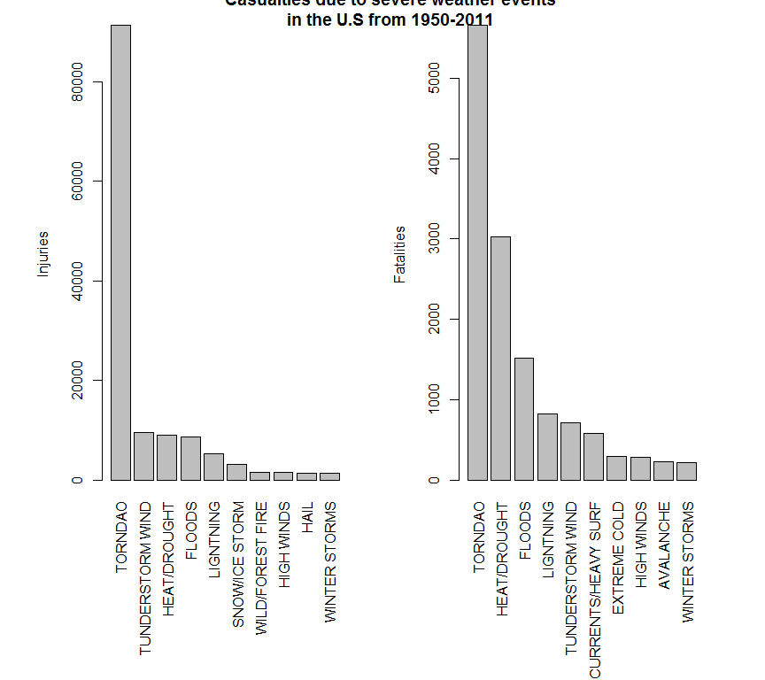

```r
par(mfrow = c(1, 2), mar = c(10, 4, 0.5, 2.5), oma = c(1.5,2, 1, 1))
barplot(injury_events$injuries, names.arg = injury_events$EVTYPE_New, ylab = "Injuries",las = 3)
barplot(fatal_events$fatalities, names.arg = fatal_events$EVTYPE_New, ylab = "Fatalities",las = 3)
title(main="Casualties due to severe weather events\nin the U.S from 1950-2011", outer = TRUE)
```

### Summary:Result of health impact

# Economic Impact of Events onto Crop & Property

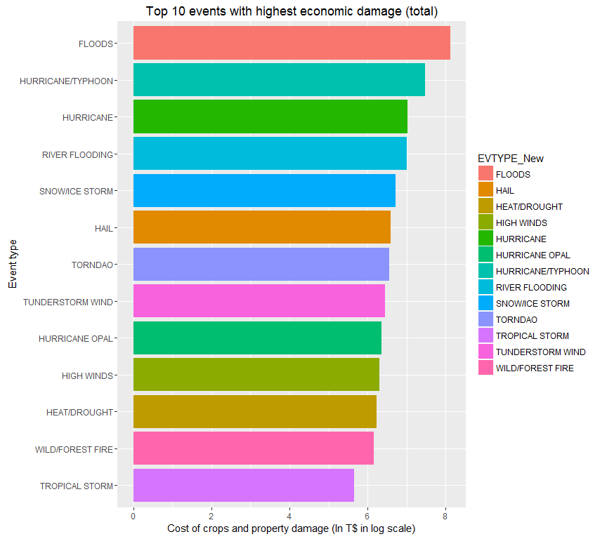

```r
total_damage<-full_join(top_crop_dmg,top_prop_dmg,by="EVTYPE_New")
total_damage1<-total_damage%>%filter(is.na(prop_dmg_total))%>%mutate(prop_dmg_total=0)
total_damage2<-total_damage%>%filter(is.na(crop_dmg_total))%>%mutate(crop_dmg_total=0)
total_damage3<-total_damage%>%filter(!is.na(crop_dmg_total)&!is.na(prop_dmg_total)) %>% select(everything())
total_damage<-union(total_damage3,total_damage2)
total_damage<-union(total_damage,total_damage1)

total_damage<-total_damage%>%group_by(EVTYPE_New)%>%transmute(dmg_total = (crop_dmg_total + prop_dmg_total)/1000 )

g <- ggplot(total_damage, aes(reorder(EVTYPE_New, dmg_total), y=log10(dmg_total))) +
geom_bar(stat = "identity", aes(fill = EVTYPE_New)) +
ylab("Cost of crops and property damage (In T$ in log scale)") +
xlab("Event type") +
ggtitle("Top 10 events with highest economic damage (total)") +
coord_flip()


plot(g)
```

Economic damages are depicted in logarithmic scale due to large range of values.

### clear workspace

```r
rm(list=ls())
```